# sanjay_12_September_2021

```python
import numpy as np
import pandas as pd
import seaborn as sns
pd.set_option('display.float_format', lambda x: '%.2f' % x)
import scipy.stats as stats
from statsmodels import stats as statmodel
import matplotlib.pyplot as plt
```

```python
df = pd.read_csv('Wholesale+Customers+Data.csv')
df.head()
```

|  | Buyer/Spender | Channel | Region | Fresh | Milk | Grocery | Frozen | Detergents_Paper | Delicatessen |
| --- | --- | --- | --- | --- | --- | --- | --- | --- | --- |
| 0 | 1 | Retail | Other | 12669 | 9656 | 7561 | 214 | 2674 | 1338 |
| 1 | 2 | Retail | Other | 7057 | 9810 | 9568 | 1762 | 3293 | 1776 |
| 2 | 3 | Retail | Other | 6353 | 8808 | 7684 | 2405 | 3516 | 7844 |
| 3 | 4 | Hotel | Other | 13265 | 1196 | 4221 | 6404 | 507 | 1788 |
| 4 | 5 | Retail | Other | 22615 | 5410 | 7198 | 3915 | 1777 | 5185 |

```python
df.describe(include="all")
```

[output not shown]

```python
df.dtypes
```

```
Buyer/Spender        int64
Channel             object
Region              object
Fresh                int64
Milk                 int64
Grocery              int64
Frozen               int64
Detergents_Paper     int64
Delicatessen         int64
dtype: object
```

```python
row, col = df.shape
print("There are total {}".format(row), "rows and {}".format(col), "columns in the dataset")
```

```
There are total 440 rows and 9 columns in the dataset
```

```python
df.info()
```

```
<class 'pandas.core.frame.DataFrame'>
RangeIndex: 440 entries, 0 to 439
Data columns (total 9 columns):
Buyer/Spender       440 non-null int64
Channel             440 non-null object
Region              440 non-null object
Fresh               440 non-null int64
Milk                440 non-null int64
Grocery             440 non-null int64
Frozen              440 non-null int64
Detergents_Paper    440 non-null int64
Delicatessen        440 non-null int64
dtypes: int64(7), object(2)
memory usage: 31.0+ KB
```

```python
df.isnull().values.any()
```

```
False
```

# question 1

## A wholesale distributor operating in different regions of Portugal has information on annual spending of several items in their stores across different regions and channels. The data consists of 440 large retailers’ annual spending on 6 different varieties of products in 3 different regions (Lisbon, Oporto, Other) and across different sales channel (Hotel, Retail).

##### 1.1 Use methods of descriptive statistics to summarize data. Which Region and which Channel spent the most? Which Region and which Channel spent the least?

```python
df['Region'].unique()
```

```
array(['Other', 'Lisbon', 'Oporto'], dtype=object)
```

```python
df["Total"]=df["Fresh"]+df["Milk"]+df["Grocery"]+df["Frozen"]+df["Detergents_Paper"]+df["Delicatessen"]
df.head()
```

|  | Buyer/Spender | Channel | Region | Fresh | Milk | Grocery | Frozen | Detergents_Paper | Delicatessen | Total |
| --- | --- | --- | --- | --- | --- | --- | --- | --- | --- | --- |
| 0 | 1 | Retail | Other | 12669 | 9656 | 7561 | 214 | 2674 | 1338 | 34112 |
| 1 | 2 | Retail | Other | 7057 | 9810 | 9568 | 1762 | 3293 | 1776 | 33266 |
| 2 | 3 | Retail | Other | 6353 | 8808 | 7684 | 2405 | 3516 | 7844 | 36610 |
| 3 | 4 | Hotel | Other | 13265 | 1196 | 4221 | 6404 | 507 | 1788 | 27381 |
| 4 | 5 | Retail | Other | 22615 | 5410 | 7198 | 3915 | 1777 | 5185 | 46100 |

```python
Groupby_region = df['Total'].groupby(df['Region']).sum().sort_values(ascending=False).head()
pd.DataFrame(Groupby_region)
```

| Region | Total |
| --- | --- |
| Other | 10677599 |
| Lisbon | 2386813 |
| Oporto | 1555088 |

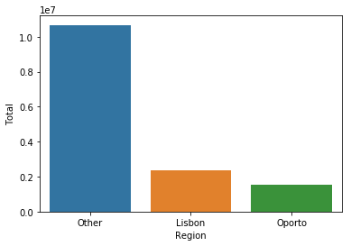

```python
Groupby_region =  Groupby_region.reset_index()
sns.barplot(x = Groupby_region['Region'], y = Groupby_region['Total'])
plt.show()
```

##### Infered from the above Barchart, The amount spent on "Other" region is higher and the Least amount is spent on the "Oporto" Region

###### Highest Region Spent - Other

###### Lowest Region Spent - Oporto

```python
Groupby_channel = df['Total'].groupby(df['Channel']).sum().sort_values(ascending=False).head()
pd.DataFrame(Groupby_channel)
```

| Channel | Total |
| --- | --- |
| Hotel | 7999569 |
| Retail | 6619931 |

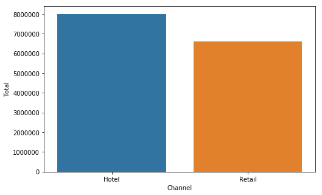

```python
Groupby_channel =  Groupby_channel.reset_index()
plt.figure(figsize=(8,5))
sns.barplot(x = Groupby_channel['Channel'], y = Groupby_channel['Total'])
plt.show()
```

###### Highest Region Spent - Hotel

###### Lowest Region Spent - Retail

###### 1.2 There are 6 different varieties of items that are considered. Describe and comment/explain all the varieties across Region and Channel? Provide a detailed justification for your answer.

```python
df.columns
```

```
Index(['Buyer/Spender', 'Channel', 'Region', 'Fresh', 'Milk', 'Grocery',
       'Frozen', 'Detergents_Paper', 'Delicatessen', 'Total'],
      dtype='object')
```

```python
item = pd.pivot_table(df, values=['Fresh', 'Milk', 'Grocery','Frozen', 'Detergents_Paper', 'Delicatessen'], index=['Region','Channel'])
item
```

| Region | Channel | Delicatessen | Detergents_Paper | Fresh | Frozen | Grocery | Milk |
| --- | --- | --- | --- | --- | --- | --- | --- |
| Lisbon | Hotel | 1197.15 | 950.53 | 12902.25 | 3127.32 | 4026.14 | 3870.20 |
|  | Retail | 1871.94 | 8225.28 | 5200.00 | 2584.11 | 18471.94 | 10784.00 |
| Oporto | Hotel | 1105.89 | 482.71 | 11650.54 | 5745.04 | 4395.50 | 2304.25 |
|  | Retail | 1239.00 | 8410.26 | 7289.79 | 1540.58 | 16326.32 | 9190.79 |
| Other | Hotel | 1518.28 | 786.68 | 13878.05 | 3656.90 | 3886.73 | 3486.98 |
|  | Retail | 1826.21 | 6899.24 | 9831.50 | 1513.20 | 15953.81 | 10981.01 |

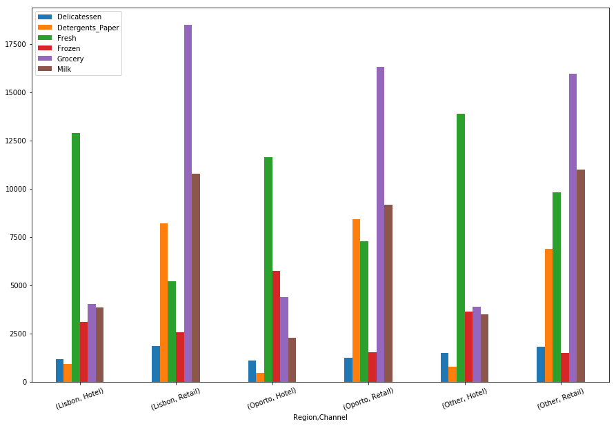

```python
item.plot(kind="bar",figsize=(15,10))
plt.xticks(rotation=20)
plt.show()
```

###### Inference from the above Pivot table and bar graph

In 'Lisbon' Region 'Delicatessen' is higher in the 'Retail' channel with that of the 'Hotel' channel. Highest amount spent on the item 'Fresh' than the other items in 'Hotel' channel, Whereas in 'Retail' channel 'Grocery' has the highest amount spent.

In 'Oporto' Region, 'Detergents_Paper' is the least amount spent in the 'Hotel' channel whereas 'Detergents_Paper' is the third highest amount spent in the 'Retail' Channel. 'Fresh' and 'Grocery' is the item where highest amount spent in the channels 'Hotel' and 'Retail'.

In 'Other' Region, the amount spent on items 'Milk','Frozen' and 'Grocery' was almost the same in the 'Hotel' channel. In 'Retail' Channel, the amount spent on the 'Frozen' is least amount spent.

#### 1.3 On the basis of a descriptive measure of variability, which item shows the most inconsistent behaviour? Which items show the least inconsistent behaviour?

```python
df.describe()
```

|  | Buyer/Spender | Fresh | Milk | Grocery | Frozen | Detergents_Paper | Delicatessen | Total |
| --- | --- | --- | --- | --- | --- | --- | --- | --- |
| count | 440.00 | 440.00 | 440.00 | 440.00 | 440.00 | 440.00 | 440.00 | 440.00 |
| mean | 220.50 | 12000.30 | 5796.27 | 7951.28 | 3071.93 | 2881.49 | 1524.87 | 33226.14 |
| std | 127.16 | 12647.33 | 7380.38 | 9503.16 | 4854.67 | 4767.85 | 2820.11 | 26356.30 |
| min | 1.00 | 3.00 | 55.00 | 3.00 | 25.00 | 3.00 | 3.00 | 904.00 |
| 25% | 110.75 | 3127.75 | 1533.00 | 2153.00 | 742.25 | 256.75 | 408.25 | 17448.75 |
| 50% | 220.50 | 8504.00 | 3627.00 | 4755.50 | 1526.00 | 816.50 | 965.50 | 27492.00 |
| 75% | 330.25 | 16933.75 | 7190.25 | 10655.75 | 3554.25 | 3922.00 | 1820.25 | 41307.50 |
| max | 440.00 | 112151.00 | 73498.00 | 92780.00 | 60869.00 | 40827.00 | 47943.00 | 199891.00 |

```python
variance_fresh = round(df['Fresh'].std()/df['Fresh'].mean(),2)
variance_Milk = round(df['Milk'].std()/df['Milk'].mean(),2)
variance_Grocery = round(df['Grocery'].std()/df['Grocery'].mean(),2)
variance_Frozen = round(df['Frozen'].std()/df['Frozen'].mean(),2)
variance_Detergents_Paper = round(df['Detergents_Paper'].std()/df['Detergents_Paper'].mean(),2)
variance_Delicatessen = round(df['Delicatessen'].std()/df['Delicatessen'].mean(),2)
print("The Variance for the Fresh ",variance_fresh)
print("The Variance for the Milk ",variance_Milk)
print("The Variance for the Grocery ",variance_Grocery)
print("The Variance for the Frozen ",variance_Frozen)
print("The Variance for the Detergents Paper ",variance_Detergents_Paper)
print("The Variance for the Delicatessen ",variance_Delicatessen)
```

```
The Variance for the Fresh  1.05
The Variance for the Milk  1.27
The Variance for the Grocery  1.2
The Variance for the Frozen  1.58
The Variance for the Detergents Paper  1.65
The Variance for the Delicatessen  1.85
```

###### From the above coefficient of variance "Delicatessen" shows the most inconsistent behaviour of "1.85" and "Fresh" shows the least inconsistent behaviour of "1.05"

##### 1.4 Are there any outliers in the data? Back up your answer with a suitable plot/technique with the help of detailed comments.

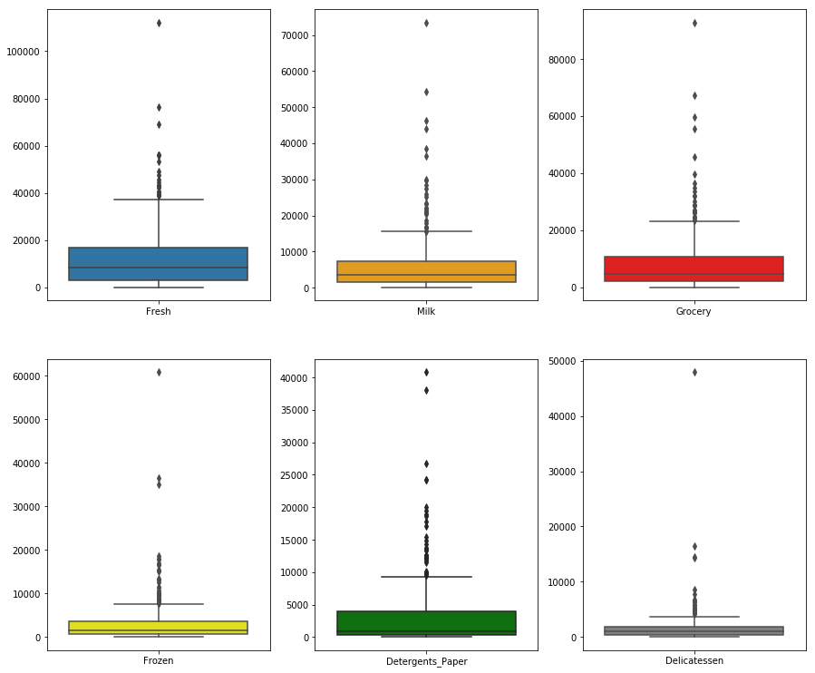

```python
fig, axes = plt.subplots(nrows=2,ncols=3)
fig.set_size_inches(15, 13)
fresh = sns.boxplot(data=df[['Fresh']] ,orient = "v" , ax=axes[0][0])
milk = sns.boxplot(data=df[[ 'Milk']] ,orient = "v" , ax=axes[0][1], color="orange")
grocery = sns.boxplot(data=df[['Grocery']] ,orient = "v" , ax=axes[0][2], color="red")
frozen = sns.boxplot(data=df[['Frozen']] ,orient = "v" , ax=axes[1][0], color="yellow")
Detergents_Paper = sns.boxplot(data=df[['Detergents_Paper']] ,orient = "v" , ax=axes[1][1], color="green")
Delicatessen = sns.boxplot(data=df[['Delicatessen']] ,orient = "v" , ax=axes[1][2], color="grey")
```

###### From the above boxplot all the items has the outliers

#### 1.5 On the basis of your analysis, what are your recommendations for the business? How can your analysis help the business to solve its problem? Answer from the business perspective

As per the analysis, I find out from the Coefficient of Variation that there are inconsistencies in spending of different items, which should be reduced. The spending for the Hotel and Retail channel should be more or less equal, but here they are different which needs to be addressed . And also spending should be equal for different regions. Need to focus on spending for other items than the “Fresh” and “Grocery”.

# question 2

## 2.The Student News Service at Clear Mountain State University (CMSU) has decided to gather data about the undergraduate students that attend CMSU. CMSU creates and distributes a survey of 14 questions and receives responses from 62 undergraduates (stored in the Survey data set).

```python
cmsu = pd.read_csv('Survey-1.csv')
cmsu.head()
```

|  | ID | Gender | Age | Class | Major | Grad Intention | GPA | Employment | Salary | Social Networking | Satisfaction | Spending | Computer | Text Messages |
| --- | --- | --- | --- | --- | --- | --- | --- | --- | --- | --- | --- | --- | --- | --- |
| 0 | 1 | Female | 20 | Junior | Other | Yes | 2.90 | Full-Time | 50.00 | 1 | 3 | 350 | Laptop | 200 |
| 1 | 2 | Male | 23 | Senior | Management | Yes | 3.60 | Part-Time | 25.00 | 1 | 4 | 360 | Laptop | 50 |
| 2 | 3 | Male | 21 | Junior | Other | Yes | 2.50 | Part-Time | 45.00 | 2 | 4 | 600 | Laptop | 200 |
| 3 | 4 | Male | 21 | Junior | CIS | Yes | 2.50 | Full-Time | 40.00 | 4 | 6 | 600 | Laptop | 250 |
| 4 | 5 | Male | 23 | Senior | Other | Undecided | 2.80 | Unemployed | 40.00 | 2 | 4 | 500 | Laptop | 100 |

```python
cmsu.describe()
```

|  | ID | Age | GPA | Salary | Social Networking | Satisfaction | Spending | Text Messages |
| --- | --- | --- | --- | --- | --- | --- | --- | --- |
| count | 62.00 | 62.00 | 62.00 | 62.00 | 62.00 | 62.00 | 62.00 | 62.00 |
| mean | 31.50 | 21.13 | 3.13 | 48.55 | 1.52 | 3.74 | 482.02 | 246.21 |
| std | 18.04 | 1.43 | 0.38 | 12.08 | 0.84 | 1.21 | 221.95 | 214.47 |
| min | 1.00 | 18.00 | 2.30 | 25.00 | 0.00 | 1.00 | 100.00 | 0.00 |
| 25% | 16.25 | 20.00 | 2.90 | 40.00 | 1.00 | 3.00 | 312.50 | 100.00 |
| 50% | 31.50 | 21.00 | 3.15 | 50.00 | 1.00 | 4.00 | 500.00 | 200.00 |
| 75% | 46.75 | 22.00 | 3.40 | 55.00 | 2.00 | 4.00 | 600.00 | 300.00 |
| max | 62.00 | 26.00 | 3.90 | 80.00 | 4.00 | 6.00 | 1400.00 | 900.00 |

```python
cmsu.dtypes
```

```
ID                     int64
Gender                object
Age                    int64
Class                 object
Major                 object
Grad Intention        object
GPA                  float64
Employment            object
Salary               float64
Social Networking      int64
Satisfaction           int64
Spending               int64
Computer              object
Text Messages          int64
dtype: object
```

```python
cmsu.shape
```

```
(62, 14)
```

```python
cmsu.isnull().values.any()
```

```
False
```

```python
cmsu.info()
```

```
<class 'pandas.core.frame.DataFrame'>
RangeIndex: 62 entries, 0 to 61
Data columns (total 14 columns):
ID                   62 non-null int64
Gender               62 non-null object
Age                  62 non-null int64
Class                62 non-null object
Major                62 non-null object
Grad Intention       62 non-null object
GPA                  62 non-null float64
Employment           62 non-null object
Salary               62 non-null float64
Social Networking    62 non-null int64
Satisfaction         62 non-null int64
Spending             62 non-null int64
Computer             62 non-null object
Text Messages        62 non-null int64
dtypes: float64(2), int64(6), object(6)
memory usage: 6.9+ KB
```

### 2.1. For this data, construct the following contingency tables (Keep Gender as row variable)

##### 2.1.1. Gender and Major

```python
Gender_Major = pd.crosstab(cmsu["Gender"],cmsu["Major"])
Gender_Major
```

| Major Gender | Accounting | CIS | Economics/Finance | International Business | Management | Other | Retailing/Marketing | Undecided |
| --- | --- | --- | --- | --- | --- | --- | --- | --- |
| Female | 3 | 3 | 7 | 4 | 4 | 3 | 9 | 0 |
| Male | 4 | 1 | 4 | 2 | 6 | 4 | 5 | 3 |

###### 2.1.2. Gender and Grad Intention

```python
Gender_Grad = pd.crosstab(cmsu["Gender"],cmsu["Grad Intention"])
Gender_Grad
```

| Grad Intention Gender | No | Undecided | Yes |
| --- | --- | --- | --- |
| Female | 9 | 13 | 11 |
| Male | 3 | 9 | 17 |

###### 2.1.3. Gender and Employment

```python
Gender_Employment = pd.crosstab(cmsu["Gender"],cmsu["Employment"])
Gender_Employment
```

| Employment Gender | Full-Time | Part-Time | Unemployed |
| --- | --- | --- | --- |
| Female | 3 | 24 | 6 |
| Male | 7 | 19 | 3 |

###### 2.1.4. Gender and Computer

```python
Gender_Computer = pd.crosstab(cmsu["Gender"],cmsu["Computer"])
Gender_Computer
```

| Computer Gender | Desktop | Laptop | Tablet |
| --- | --- | --- | --- |
| Female | 2 | 29 | 2 |
| Male | 3 | 26 | 0 |

### 2.2. Assume that the sample is representative of the population of CMSU. Based on the data, answer the following question:

###### 2.2.1. What is the probability that a randomly selected CMSU student will be male?

```python
gender_count = cmsu["Gender"].value_counts()
pd.DataFrame(gender_count)
```

|  | Gender |
| --- | --- |
| Female | 33 |
| Male | 29 |

```python
cmsu_male = gender_count["Male"]/gender_count.sum()
print(cmsu_male)
cmsu_male = cmsu_male * 100
print("The probability of selected male candidate of CMSU population is", format(round(cmsu_male,2)),"%")
```

```
0.46774193548387094
The probability of selected male candidate of CMSU population is 46.77 %
```

###### 2.2.2. What is the probability that a randomly selected CMSU student will be female?

```python
cmsu_female = gender_count["Female"]/gender_count.sum()
print(cmsu_female)
cmsu_female = cmsu_female * 100
print("The probability of selected male candidate of CMSU population is", format(round(cmsu_female,2)),"%")
```

```
0.532258064516129
The probability of selected male candidate of CMSU population is 53.23 %
```

### 2.3. Assume that the sample is representative of the population of CMSU. Based on the data, answer the following question:

###### 2.3.1. Find the conditional probability of different majors among the male students in CMSU.

```python
Gender_Major
```

| Major Gender | Accounting | CIS | Economics/Finance | International Business | Management | Other | Retailing/Marketing | Undecided |
| --- | --- | --- | --- | --- | --- | --- | --- | --- |
| Female | 3 | 3 | 7 | 4 | 4 | 3 | 9 | 0 |
| Male | 4 | 1 | 4 | 2 | 6 | 4 | 5 | 3 |

```python
2/gender_count["Male"]
```

```
0.06896551724137931
```

```python
Accounting_accounting = Gender_Major["Accounting"]["Male"]/gender_count["Male"]
Accounting_cis = Gender_Major["CIS"]["Male"]/gender_count["Male"]
Accounting_economics = Gender_Major["Economics/Finance"]["Male"]/gender_count["Male"]
Accounting_International = Gender_Major["International Business"]["Male"]/gender_count["Male"]
Accounting_Management = Gender_Major["Management"]["Male"]/gender_count["Male"]
Accounting_Other = Gender_Major["Other"]["Male"]/gender_count["Male"]
Accounting_Retailing = Gender_Major["Retailing/Marketing"]["Male"]/gender_count["Male"]
Accounting_Undecided = Gender_Major["Undecided"]["Male"]/gender_count["Male"]


print("The probability of selected male candidate for Accounting major is ", format(round((Accounting_accounting*100),2)),"%")
print("The probability of selected male candidate for CIS major is ", format(round((Accounting_cis*100),2)),"%")
print("The probability of selected male candidate for Economics/Finance major is ", format(round((Accounting_economics*100),2)),"%")
print("The probability of selected male candidate for International Business major is ", format(round((Accounting_International*100),2)),"%")
print("The probability of selected male candidate for Management major is ", format(round((Accounting_Management*100),2)),"%")
print("The probability of selected male candidate for Other major is", format(round((Accounting_Other*100),2)),"%")
print("The probability of selected male candidate for Retailing/Marketing major is ", format(round((Accounting_Retailing*100),2)),"%")
print("The probability of selected male candidate for Undecided major is ", format(round((Accounting_Undecided*100),2)),"%")
```

```
The probability of selected male candidate for Accounting major is  13.79 %
The probability of selected male candidate for CIS major is  3.45 %
The probability of selected male candidate for Economics/Finance major is  13.79 %
The probability of selected male candidate for International Business major is  6.9 %
The probability of selected male candidate for Management major is  20.69 %
The probability of selected male candidate for Other major is 13.79 %
The probability of selected male candidate for Retailing/Marketing major is  17.24 %
The probability of selected male candidate for Undecided major is  10.34 %
```

###### 2.3.2 Find the conditional probability of different majors among the female students of CMSU.

```python
Female_Accounting_accounting = Gender_Major["Accounting"]["Female"]/gender_count["Female"]
Female_Accounting_cis = Gender_Major["CIS"]["Female"]/gender_count["Female"]
Female_Accounting_economics = Gender_Major["Economics/Finance"]["Female"]/gender_count["Female"]
Female_Accounting_International = Gender_Major["International Business"]["Female"]/gender_count["Female"]
Female_Accounting_Management = Gender_Major["Management"]["Female"]/gender_count["Female"]
Female_Accounting_Other = Gender_Major["Other"]["Female"]/gender_count["Female"]
Female_Accounting_Retailing = Gender_Major["Retailing/Marketing"]["Female"]/gender_count["Female"]
Female_Accounting_Undecided = Gender_Major["Undecided"]["Female"]/gender_count["Female"]


print("The probability of selected Female candidate for Accounting major is ", format(round((Female_Accounting_accounting*100),2)),"%")
print("The probability of selected Female candidate for CIS major is ", format(round((Female_Accounting_cis*100),2)),"%")
print("The probability of selected Female candidate for Economics/Finance major is ", format(round((Female_Accounting_economics*100),2)),"%")
print("The probability of selected Female candidate for International Business major is ", format(round((Female_Accounting_International*100),2)),"%")
print("The probability of selected Female candidate for Management major is ", format(round((Female_Accounting_Management*100),2)),"%")
print("The probability of selected Female candidate for Other major is", format(round((Female_Accounting_Other*100),2)),"%")
print("The probability of selected Female candidate for Retailing/Marketing major is ", format(round((Female_Accounting_Retailing*100),2)),"%")
print("The probability of selected Female candidate for Undecided major is ", format(round((Female_Accounting_Undecided*100),2)),"%")
```

```
The probability of selected Female candidate for Accounting major is  9.09 %
The probability of selected Female candidate for CIS major is  9.09 %
The probability of selected Female candidate for Economics/Finance major is  21.21 %
The probability of selected Female candidate for International Business major is  12.12 %
The probability of selected Female candidate for Management major is  12.12 %
The probability of selected Female candidate for Other major is 9.09 %
The probability of selected Female candidate for Retailing/Marketing major is  27.27 %
The probability of selected Female candidate for Undecided major is  0.0 %
```

### 2.4. Assume that the sample is a representative of the population of CMSU. Based on the data, answer the following question:

###### 2.4.1. Find the probability That a randomly chosen student is a male and intends to graduate.

```python
Gender_Grad.T
```

| Gender Grad Intention | Female | Male |
| --- | --- | --- |
| No | 9 | 3 |
| Undecided | 13 | 9 |
| Yes | 11 | 17 |

```python
gender_count
```

```
Female    33
Male      29
Name: Gender, dtype: int64
```

```python
intend_tograd = Gender_Grad["Yes"]["Male"]/gender_count.sum()
print(intend_tograd)
print("The probability of selected Male candidate and intends to graduate are ", format(round(intend_tograd*100,2)),"%")
```

```
0.27419354838709675
The probability of selected Male candidate and intends to graduate are  27.42 %
```

###### 2.4.2 Find the probability that a randomly selected student is a female and does NOT have a laptop.

```python
Gender_Computer
```

[output not shown]

```python
female_No_laptop = (Gender_Computer["Desktop"]["Female"]+Gender_Computer["Tablet"]["Female"])/gender_count.sum()
print(female_No_laptop)
print("The probability of selected Female candidate and does not have a laptop are ", format(round(female_No_laptop*100,2)),"%")
```

```
0.06451612903225806
The probability of selected Female candidate and does not have a laptop are  6.45 %
```

### 2.5. Assume that the sample is a representative of the population of CMSU. Based on the data, answer the following question:

###### 2.5.1 Find the probability that a randomly chosen student is a male or has a full-time employment

```python
Gender_Empt = Gender_Employment.T
Gender_Empt
```

| Gender Employment | Female | Male |
| --- | --- | --- |
| Full-Time | 3 | 7 |
| Part-Time | 24 | 19 |
| Unemployed | 6 | 3 |

```python
male_FT = (Gender_Empt["Male"].sum() + Gender_Employment["Full-Time"].sum() - Gender_Employment["Full-Time"]["Male"])/gender_count.sum()
print(male_FT)
print("The probability of selected Male candidate or with full-time employment are ", format(round(male_FT*100,2)),"%")
```

```
0.5161290322580645
The probability of selected Male candidate or with full-time employment are  51.61 %
```

###### 2.5.2. Find the conditional probability that given a female student is randomly chosen, she is majoring in international business or management.

```python
Gender_Major.T
```

| Gender Major | Female | Male |
| --- | --- | --- |
| Accounting | 3 | 4 |
| CIS | 3 | 1 |
| Economics/Finance | 7 | 4 |
| International Business | 4 | 2 |
| Management | 4 | 6 |
| Other | 3 | 4 |
| Retailing/Marketing | 9 | 5 |
| Undecided | 0 | 3 |

```python
Gender_Major["International Business"]
```

```
Gender
Female    4
Male      2
Name: International Business, dtype: int64
```

```python
(Gender_Major.T["Female"].sum()/gender_count.sum()) + (Gender_Major["International Business"].sum()/gender_count.sum()) + (Gender_Major["Management"].sum()/gender_count.sum()) - (Gender_Major.T["Female"]["International Business"].sum()/gender_count.sum()) - (Gender_Major.T["Female"]["Management"].sum()/gender_count.sum())
```

```
0.6612903225806452
```

```python
(33/62)*((4+4)/33)
```

```
0.12903225806451613
```

###### 2.6. Construct a contingency table of Gender and Intent to Graduate at 2 levels (Yes/No). The Undecided students are not considered now and the table is a 2x2 table. Do you think the graduate intention and being female are independent events?

```python
cmsu.head()
print(cmsu['Grad Intention'].value_counts())
print()
cmsu_grad = cmsu[(cmsu['Grad Intention'] == "Yes") | (cmsu['Grad Intention'] == "No")]
cmsu_grad['Grad Intention'].value_counts()
```

```
Yes          28
Undecided    22
No           12
Name: Grad Intention, dtype: int64
```

```
Yes    28
No     12
Name: Grad Intention, dtype: int64
```

```python
pd.crosstab(index=cmsu_grad['Gender'], columns=cmsu_grad['Grad Intention'])
```

| Grad Intention Gender | No | Yes |
| --- | --- | --- |
| Female | 9 | 11 |
| Male | 3 | 17 |

No, Graduate intention and Female Gender are not independent event. Both are dependent events Female gender can have graduate intentions(Yes and No)

### 2.7. Note that there are four numerical (continuous) variables in the data set, GPA, Salary, Spending, and Text Messages.

Answer the following questions based on the data

###### 2.7.1. If a student is chosen randomly, what is the probability that his/her GPA is less than 3?

```python
GPA_LT3 = cmsu[(cmsu['GPA'] < 3)]["GPA"].count() / cmsu["GPA"].count()
GPA_LT3
```

```
0.27419354838709675
```

```python
print("The probability of selected candidates with GPA less than 3 is ", format(round(GPA_LT3*100,2)),"%")
```

```
The probability of selected candidates with GPA less than 3 is  27.42 %
```

###### 2.7.2. Find the conditional probability that a randomly selected male earns 50 or more. Find the conditional probability that a randomly selected female earns 50 or more.

```python
cmsu.head()
```

|  | ID | Gender | Age | Class | Major | Grad Intention | GPA | Employment | Salary | Social Networking | Satisfaction | Spending | Computer | Text Messages |
| --- | --- | --- | --- | --- | --- | --- | --- | --- | --- | --- | --- | --- | --- | --- |
| 0 | 1 | Female | 20 | Junior | Other | Yes | 2.90 | Full-Time | 50.00 | 1 | 3 | 350 | Laptop | 200 |
| 1 | 2 | Male | 23 | Senior | Management | Yes | 3.60 | Part-Time | 25.00 | 1 | 4 | 360 | Laptop | 50 |
| 2 | 3 | Male | 21 | Junior | Other | Yes | 2.50 | Part-Time | 45.00 | 2 | 4 | 600 | Laptop | 200 |
| 3 | 4 | Male | 21 | Junior | CIS | Yes | 2.50 | Full-Time | 40.00 | 4 | 6 | 600 | Laptop | 250 |
| 4 | 5 | Male | 23 | Senior | Other | Undecided | 2.80 | Unemployed | 40.00 | 2 | 4 | 500 | Laptop | 100 |

```python
cmsu["Gender"].count()
```

```
62
```

```python
cmsu[(cmsu['Salary'] >= 50) & (cmsu["Gender"] == "Male")]["Salary"].count()
```

```
14
```

```python
earning_male = cmsu[(cmsu['Salary'] >= 50) & (cmsu["Gender"] == "Male")]["Salary"].count() / cmsu["Gender"].count()
earning_male
```

```
0.22580645161290322
```

```python
print("The probability of selected Male candidates where ", format(round(earning_male*100,2)),"% whose salary is  50 or more ")
```

```
The probability of selected Male candidates where  22.58 % whose salary is  50 or more
```

```python
cmsu[(cmsu['Salary'] >= 50) & (cmsu["Gender"] == "Female")]["Salary"].count()
```

```
18
```

```python
earning_female = cmsu[(cmsu['Salary'] >= 50) & (cmsu["Gender"] == "Female")]["Salary"].count() / cmsu["Gender"].count()
earning_female
```

```
0.2903225806451613
```

```python
print("The probability of selected Female candidates where ", format(round(earning_female*100,2)),"% whose salary is  50 or more ")
```

```
The probability of selected Female candidates where  29.03 % whose salary is  50 or more
```

###### 2.8. Note that there are four numerical (continuous) variables in the data set, GPA, Salary, Spending, and Text Messages. For each of them comment whether they follow a normal distribution. Write a note summarizing your conclusions.

```python
cmsu.head()
```

|  | ID | Gender | Age | Class | Major | Grad Intention | GPA | Employment | Salary | Social Networking | Satisfaction | Spending | Computer | Text Messages |
| --- | --- | --- | --- | --- | --- | --- | --- | --- | --- | --- | --- | --- | --- | --- |
| 0 | 1 | Female | 20 | Junior | Other | Yes | 2.90 | Full-Time | 50.00 | 1 | 3 | 350 | Laptop | 200 |
| 1 | 2 | Male | 23 | Senior | Management | Yes | 3.60 | Part-Time | 25.00 | 1 | 4 | 360 | Laptop | 50 |
| 2 | 3 | Male | 21 | Junior | Other | Yes | 2.50 | Part-Time | 45.00 | 2 | 4 | 600 | Laptop | 200 |
| 3 | 4 | Male | 21 | Junior | CIS | Yes | 2.50 | Full-Time | 40.00 | 4 | 6 | 600 | Laptop | 250 |
| 4 | 5 | Male | 23 | Senior | Other | Undecided | 2.80 | Unemployed | 40.00 | 2 | 4 | 500 | Laptop | 100 |

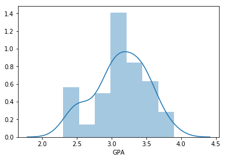

```python
sns.distplot(cmsu["GPA"])
```

```python
print("mean ",cmsu["GPA"].mean(),"\n")
print("Mode - ",cmsu["GPA"].mode(),"\n")
print("Median - ",cmsu["GPA"].median(),"\n")

print("Shapiro test")
stat, p = stats.shapiro(cmsu["GPA"])
print("P- value -",p)
print()
print("Mean,Mode and Median are approximately equal and from the Shapiro test GPA follows the normal distribution")
```

```
mean  3.129032258064516

Mode -  0   3.00
1   3.10
2   3.40
dtype: float64

Median -  3.1500000000000004

Shapiro test
P- value - 0.11204058676958084

Mean,Mode and Median are approximately equal and from the Shapiro test GPA follows the normal distribution
```

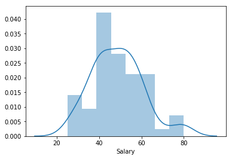

```python
sns.distplot(cmsu["Salary"])
```

```python
print("mean - ",cmsu["Salary"].mean(),"\n")
print("Mode - ",cmsu["Salary"].mode(),"\n")
print("Median - ",cmsu["Salary"].median(),"\n")

print("Shapiro test")
stat, p = stats.shapiro(cmsu["Salary"])
print("P- value -",p)
print()
print("Mean,Mode and Median are approximately equal and from the Shapiro test, Salary does not follows the normal distribution")
```

```
mean -  48.54838709677419

Mode -  0   40.00
dtype: float64

Median -  50.0

Shapiro test
P- value - 0.028000956401228905

Mean,Mode and Median are approximately equal and from the Shapiro test, Salary does not follows the normal distribution
```

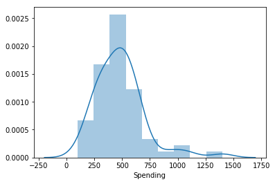

```python
sns.distplot(cmsu["Spending"])
```

```python
print("mean - ",cmsu["Spending"].mean(),"\n")
print("Mode - ",cmsu["Spending"].mode(),"\n")
print("Median -",cmsu["Spending"].median(),"\n")
print("Shapiro test")
stat, p = stats.shapiro(cmsu["Spending"])
print("P- value -",p)
print()
print("Mean,Mode and Median are approximately equal and from the shapiro test, Spending does not follows the normal distribution")
```

```
mean -  482.01612903225805

Mode -  0    500
dtype: int64

Median - 500.0

Shapiro test
P- value - 1.6854661225806922e-05

Mean,Mode and Median are approximately equal and from the shapiro test, Spending does not follows the normal distribution
```

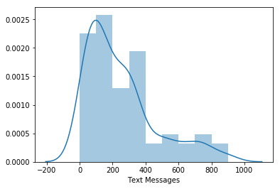

```python
sns.distplot(cmsu["Text Messages"])
```

```python
print("mean - ",cmsu["Text Messages"].mean(),"\n")
print("mode - ",cmsu["Text Messages"].mode(),"\n")
print("median - ",cmsu["Text Messages"].median(),"\n")
print("Shapiro test")
stat, p = stats.shapiro(cmsu["Text Messages"])
print("P- value -",p)
print()
print("Mean,Mode and Median are approximately equal and from the shapiro test, Text Messages does not follows the normal distribution")
```

[output not shown]

###### p-value(0.11204058676958084) > alpha(0.05) from the shapiro test, GPA follows the normal distribution

###### whereas, p-value < alpha(0.05) Salary, Spending, and Text Messages does not follow normal distribution

# Question - 3

# An important quality characteristic used by the manufacturers of ABC asphalt shingles is the amount of moisture the shingles contain when they are packaged. Customers may feel that they have purchased a product lacking in quality if they find moisture and wet shingles inside the packaging. In some cases, excessive moisture can cause the granules attached to the shingles for texture and coloring purposes to fall off the shingles resulting in appearance problems. To monitor the amount of moisture present, the company conducts moisture tests. A shingle is weighed and then dried. The shingle is then reweighed, and based on the amount of moisture taken out of the product, the pounds of moisture per 100 square feet are calculated. The company would like to show that the mean moisture content is less than 0.35 pounds per 100 square feet.

```python
ab = pd.read_csv('A+&+B+shingles.csv')
ab.head()
```

|  | A | B |
| --- | --- | --- |
| 0 | 0.44 | 0.14 |
| 1 | 0.61 | 0.15 |
| 2 | 0.47 | 0.31 |
| 3 | 0.30 | 0.16 |
| 4 | 0.15 | 0.37 |

```python
ab.describe()
```

|  | A | B |
| --- | --- | --- |
| count | 36.00 | 31.00 |
| mean | 0.32 | 0.27 |
| std | 0.14 | 0.14 |
| min | 0.13 | 0.10 |
| 25% | 0.21 | 0.16 |
| 50% | 0.29 | 0.23 |
| 75% | 0.39 | 0.40 |
| max | 0.72 | 0.58 |

```python
ab.dtypes
```

```
A    float64
B    float64
dtype: object
```

```python
ab.shape
```

```
(36, 2)
```

```python
ab.info()
```

```
<class 'pandas.core.frame.DataFrame'>
RangeIndex: 36 entries, 0 to 35
Data columns (total 2 columns):
A    36 non-null float64
B    31 non-null float64
dtypes: float64(2)
memory usage: 656.0 bytes
```

```python
ab.isnull().values.any()
```

```
True
```

###### 3.1 Do you think there is evidence that means moisture contents in both types of shingles are within the permissible limits? State your conclusions clearly showing all steps.

#### For A

###### Step - 1

H0 : mu >= 0.35

H1 : mu < 0.35

###### Step-2

```python
 alpha = 0.05  # Level of significance
```

###### ###### Step-3

T statistics test

###### Step-4

```python
t_statistic, p_value = stats.ttest_1samp(ab.A, 0.35)
print("t statistic - ",t_statistic,"P - Value -", p_value)
```

```
t statistic -  -1.4735046253382782 P - Value - 0.14955266289815025
```

###### Step - 5

```python
print('Level of significance: %.2f' %alpha)
if (p_value/2) < alpha:
    print('We have evidence to reject the null hypothesis since p value < Level of significance')
else:
    print('We have no evidence to reject the null hypothesis since p value > Level of significance')

print ("Our one-sample t-test p-value=", p_value/2)
```

```
Level of significance: 0.05
We have no evidence to reject the null hypothesis since p value > Level of significance
Our one-sample t-test p-value= 0.07477633144907513
```

###### Step - 4

```python
t_statistic_B, p_value_B = stats.ttest_1samp(ab.B, 0.35,nan_policy='omit' )
print("t statistic - ",t_statistic_B,"P - Value -", p_value_B)
```

```
t statistic -  -3.1003313069986995 P - Value - 0.004180954800638365
```

###### Step - 5

```python
print('Level of significance: %.2f' %alpha)
if (p_value_B/2) < alpha:
    print('We have evidence to reject the null hypothesis since p value < Level of significance')
else:
    print('We have no evidence to reject the null hypothesis since p value > Level of significance')

print ("Our one-sample t-test p-value=", p_value_B/2)
```

```
Level of significance: 0.05
We have evidence to reject the null hypothesis since p value < Level of significance
Our one-sample t-test p-value= 0.0020904774003191826
```

###### 3.2 Do you think that the population mean for shingles A and B are equal? Form the hypothesis and conduct the test of the hypothesis. What assumption do you need to check before the test for equality of means is performed?

###### Step - 1

H0 : mu_A == mu_B

H1 : mu_A != mu_B

###### Step - 2

```python
alpha = 0.05
```

###### step - 3

2 sample t test

###### step - 4

```python
t_statistic, p_value  = stats.ttest_ind(ab['A'],ab['B'],nan_policy='omit' )
print('tstat - ',t_statistic)
print('P Value - ',p_value)
```

```
tstat -  1.2896282719661123
P Value -  0.2017496571835306
```

###### Step - 5

```python
print('Level of significance: %.2f' %alpha)
if (p_value) < alpha:
    print('We have evidence to reject the null hypothesis since p value < Level of significance')
else:
    print('We have no evidence to reject the null hypothesis since p value > Level of significance')

print ("Our two-sample t-test p-value=", p_value)
```

```
Level of significance: 0.05
We have no evidence to reject the null hypothesis since p value > Level of significance
Our two-sample t-test p-value= 0.2017496571835306
```

Assumptions,

The Population to be normal and the variance of the two companies needs to be equal. If these assumptions were not met, then needs to proceed with alternate hypothesis testing.